# Analyzing Price and Graduation

Leandro Ledesma

2024-03-17

The function of this document is to go through the process of multiple regression based on the teachings of my ELCS 8330 class. The goal is to take some data that we downloaded from the Integrated Postsecondary Education Data System (IPEDS) and to investigate the relationship between the price of attending an institution and its relationship to graduation rate.

The following document is going to go over the cleaning process of the data, checking of pre-estimation assumptions, the analysis process (including refinements), and then the post-estimation assumptions.

### Universal block code settings

```r
knitr::opts_chunk$set(echo = TRUE)
knitr::opts_chunk$set(message = FALSE)
knitr::opts_chunk$set(comment = NULL)
```

### Load in the data manipulation packages first

```r
library(tidyverse)
library(ggplot2)
library(readxl)
library(rempsyc) # Create APA tables with nice_table()
library(flextable) # Adds aesthetic functions to the table from above
library(kableExtra) # Extra table formatting type
library(corrtable) # Potential correlation matrix code
library(broom) # Converts regression outputs into dataframes using the tidy() function
library(car) # To calcualte vif
```

### Load in the data

```r
# set working directory
setwd("C:/Users/lledesma.TIMES/Documents/MISC/ELCS 8330")

# load in the data
data.uncleaned <- read.csv("MidTermData.csv")
```

### Data cleaning

Let’s rename some of the variables to make them easier to understand. With the variable ‘Institution’ as an exemption, we see that all of our variables are being interpreted as integers. This however, is incorrect. Some of these variables have numeric values that function as labels. Thus the variables HBCU, Tribal, Carnegie and Land.Grant need to be changed to categorical.

Our dimensions show that we have 814 rows and 23 variables.

```r
# Renaming our predictor and dependent variables
data <- data.uncleaned %>%
  rename(Institution.ID = UnitID,
         Institution = Institution.Name,
         Institution.Sector = Sector.of.institution..HD2022.,
         Federal = Federal.operating.grants.and.contracts..F2122_F1A.,
         State = State.operating.grants.and.contracts..F2122_F1A.,
         `American Indian(%)` = Percent.of.total.enrollment.that.are.American.Indian.or.Alaska.Native..DRVEF2022.,
         `Asian(%)` = Percent.of.total.enrollment.that.are.Asian..DRVEF2022.,
         `Hawaii(%)` = Percent.of.total.enrollment.that.are.Native.Hawaiian.or.Other.Pacific.Islander..DRVEF2022.,
         `Black(%)` = Percent.of.total.enrollment.that.are.Black.or.African.American..DRVEF2022.,
         `Hispanic(%)` = Percent.of.total.enrollment.that.are.Hispanic.Latino..DRVEF2022.,
         `White(%)` = Percent.of.total.enrollment.that.are.White..DRVEF2022.,
         `Unknown Ethnicity(%)` = Percent.of.total.enrollment.that.are.Race.ethnicity.unknown..DRVEF2022.,
         `Non-Resident(%)` = Percent.of.total.enrollment.that.are.U.S..Nonresident..DRVEF2022.,
         `Two or more race(%)` = Percent.of.total.enrollment.that.are.two.or.more.races..DRVEF2022.,
         `Women(%)` = Percent.of.total.enrollment.that.are.women..DRVEF2022.,
         `Total Enrollment` = Total..enrollment..DRVEF2022.,
         Graduation.Rate = Graduation.rate..total.cohort..DRVGR2022.,
         HBCU = Historically.Black.College.or.University..HD2021.,
         Tribal = Tribal.college..HD2021.,
         Carnegie = Carnegie.Classification.2021..Basic..HD2021.,
         Land.Grant = Land.Grant.Institution..HD2021.,
         Price = Total.price.for.in.district.students.living.on.campus..2021.22..DRVIC2021.,
         `Admitted(%)` = Percent.admitted...total..DRVADM2021_RV.)

# View the data
str(data)
```

```
'data.frame':   814 obs. of  23 variables:
 $ Institution.ID      : int  180203 138558 126182 200697 100654 100724 138716 175342 168607 240736 ...
 $ Institution         : chr  "Aaniiih Nakoda College" "Abraham Baldwin Agricultural College" "Adams State University" "Air Force Institute of Technology-Graduate School of Engineering & Management" ...
 $ Institution.Sector  : int  1 1 1 1 1 1 1 1 1 1 ...
 $ Federal             : int  7230074 156386 5657538 NA 50875247 37849487 13878889 29999903 2820715 6647001 ...
 $ State               : int  0 0 19845305 NA 1431067 4010325 422453 198603 473149 0 ...
 $ American Indian(%)  : int  92 0 1 0 0 0 0 0 3 0 ...
 $ Asian(%)            : int  0 1 2 7 0 0 0 0 2 1 ...
 $ Hawaii(%)           : int  0 0 1 1 0 0 0 0 0 88 ...
 $ Black(%)            : int  0 9 6 5 86 90 79 95 2 0 ...
 $ Hispanic(%)         : int  0 8 28 6 1 1 5 1 3 0 ...
 $ White(%)            : int  8 79 49 70 2 4 9 2 90 0 ...
 $ Unknown Ethnicity(%): int  0 0 9 5 8 1 4 0 1 0 ...
 $ Non-Resident(%)     : int  0 1 1 1 2 2 0 1 0 11 ...
 $ Two or more race(%) : int  0 1 4 5 1 1 2 0 0 0 ...
 $ Women(%)            : int  58 60 58 18 61 65 75 68 53 72 ...
 $ Total Enrollment    : int  115 3647 2854 1048 6007 3828 6334 2933 1536 1051 ...
 $ Graduation.Rate     : int  29 40 28 NA 27 28 28 47 44 33 ...
 $ HBCU                : int  2 2 2 2 1 1 1 1 2 2 ...
 $ Tribal              : int  1 2 2 2 2 2 2 2 2 2 ...
 $ Carnegie            : int  33 23 18 16 18 17 19 20 14 14 ...
 $ Land.Grant          : int  1 2 2 2 1 2 2 1 2 1 ...
 $ Price               : int  NA 15727 23797 NA 24234 22110 21730 23812 14580 NA ...
 $ Admitted(%)         : int  NA 75 100 NA 72 98 NA 39 NA NA ...
```

```r
# Changing variables to categorical
data$HBCU <- as.character(data$HBCU)
data$Tribal <- as.character(data$Tribal)
data$Carnegie <- as.character(data$Carnegie)
data$Land.Grant <- as.character(data$Land.Grant)

# View the dimensions of our data
dim(data)
```

```
[1] 814  23
```

### Missing data

Let’s check for missing data in our dataset. If present, let’s drop those rows. After dropping for any NA’s in our dataset, our dimensions changed from 814 x 23 to 472 x 23. This means that our number of institutions, aka our n has dropped to 472. This will be our final sample size.

```r
# Check for missing data by variable
# find location of missing values
print("The number of missing data for each variable is:")
```

```
[1] "The number of missing data for each variable is:"
```

```r
colSums(is.na(data))
```

```
      Institution.ID          Institution   Institution.Sector
                   0                    0                    0
             Federal                State   American Indian(%)
                  56                   56                    8
            Asian(%)            Hawaii(%)             Black(%)
                   8                    8                    8
         Hispanic(%)             White(%) Unknown Ethnicity(%)
                   8                    8                    8
     Non-Resident(%)  Two or more race(%)             Women(%)
                   8                    8                    8
    Total Enrollment      Graduation.Rate                 HBCU
                   8                   50                   24
              Tribal             Carnegie           Land.Grant
                  24                   24                   24
               Price          Admitted(%)
                 229                  281
```

```r
# As of right now we will be dropping any row that has any NA's, this is because rows with NA's are automatically dropped during the analysis anyway- which is proven by a mismatched between the original dataset with NA's and the created vector of residuals.
data <- data %>%
  filter(complete.cases(.))


# Dimensions of new dataset
dim(data)
```

```
[1] 472  23
```

```r
# Are there any more NA's present?
print("The number of missing data for each variable is:")
```

```
[1] "The number of missing data for each variable is:"
```

```r
colSums(is.na(data))
```

```
      Institution.ID          Institution   Institution.Sector
                   0                    0                    0
             Federal                State   American Indian(%)
                   0                    0                    0
            Asian(%)            Hawaii(%)             Black(%)
                   0                    0                    0
         Hispanic(%)             White(%) Unknown Ethnicity(%)
                   0                    0                    0
     Non-Resident(%)  Two or more race(%)             Women(%)
                   0                    0                    0
    Total Enrollment      Graduation.Rate                 HBCU
                   0                    0                    0
              Tribal             Carnegie           Land.Grant
                   0                    0                    0
               Price          Admitted(%)
                   0                    0
```

### Descriptive statistics of our predictor and outcome variable

```r
# Print out the descriptive statistics using the summary function
# Main predictor variable
summary(data$Price)
```

```
   Min. 1st Qu.  Median    Mean 3rd Qu.    Max.
   4780   23037   25632   26055   28675   41473
```

```r
sd(data$Price)
```

```
[1] 4574.727
```

```r
max(data$Price)
```

```
[1] 41473
```

```r
min(data$Price)
```

```
[1] 4780
```

```r
# Main outcome variable
summary(data$Graduation.Rate)
```

```
   Min. 1st Qu.  Median    Mean 3rd Qu.    Max.
  17.00   45.00   54.00   55.44   65.00   95.00
```

```r
sd(data$Graduation.Rate)
```

```
[1] 15.72914
```

```r
max(data$Graduation.Rate)
```

```
[1] 95
```

```r
min(data$Graduation.Rate)
```

```
[1] 17
```

### Visulize the outcome variable

Let’s create histograms of our outcome variable

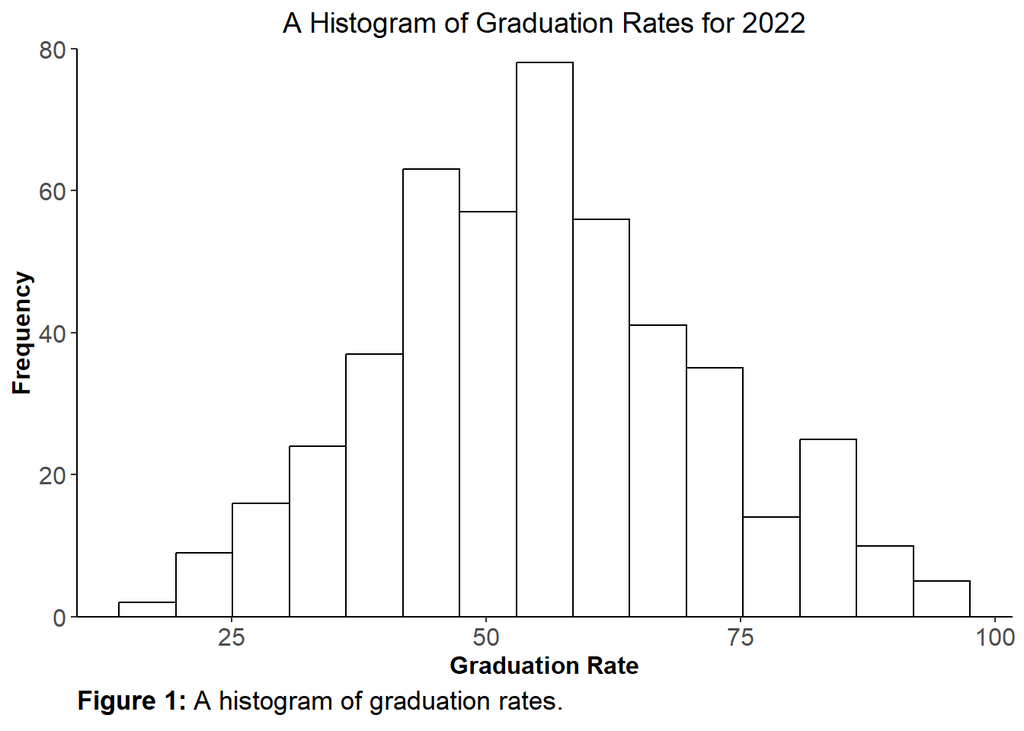

```r
# Create a histogram of the outcome variable
data %>%
  ggplot(aes(x = Graduation.Rate)) +
  geom_histogram(fill = "white",
                 color = "black",
                 bins = 15) +
  scale_y_continuous(expand = c(0,0), limits = c(0,80)) +
  theme_classic() +
  labs(title = "A Histogram of Graduation Rates for 2022",
       x = "Graduation Rate",
       y = "Frequency",
       #caption = "Figure 1: A histogram of graduation rates",
       caption = bquote(bold("Figure 1:") ~ "A histogram of graduation rates.")) +
  theme(plot.title = element_text(size = 14,
                                  hjust = 0.5),
        axis.title = element_text(size = 12,
                                  face = "bold"),
        axis.text = element_text(size = 12),
        plot.caption = element_text(size = 13,
                                    hjust = 0))
```

### Demographic descriptive statistics

```r
# Show the demographic descriptive statistics in a table
demo <- data %>%
  select(`American Indian(%)`,
         `Asian(%)`,
         `Hawaii(%)`,
         `Black(%)`,
         `Hispanic(%)`,
         `White(%)`,
         `Unknown Ethnicity(%)`,
         `Non-Resident(%)`,
         `Two or more race(%)`,
         `Women(%)`)

# We nee to have our demographic variables in one column, let's make the data longer to do this
demo.long <- demo %>%
  stack() %>%
  select(Characteristics = ind,
         Percentage = values)

# Obtain the descriptive statistics from the long format demographic sheet
demo.summarize <- demo.long %>%
  group_by(Characteristics) %>%
  summarize(Mean = round(mean(Percentage),2),
            Med. = round(median(Percentage),2),
            SD = round(sd(Percentage),2),
            Min. = min(Percentage),
            Max. = max(Percentage),
            N = nrow(demo))

# Create an APA style table with the results
demo.summarize %>%
  nice_table(title = "Table 1: Descriptive Statistics of Demographic Charactersitics") %>%
  bold(part = "header")
```

| Table 1: Descriptive Statistics of Demographic Charactersitics Characteristics | Table 1: Descriptive Statistics of Demographic Charactersitics Mean | Table 1: Descriptive Statistics of Demographic Charactersitics Med. | Table 1: Descriptive Statistics of Demographic Charactersitics SD | Table 1: Descriptive Statistics of Demographic Charactersitics Min. | Table 1: Descriptive Statistics of Demographic Charactersitics Max. | Table 1: Descriptive Statistics of Demographic Charactersitics N |
| --- | --- | --- | --- | --- | --- | --- |
| American Indian(%) | 0.99 | 0.00 | 5.58 | 0 | 100 | 472 |
| Asian(%) | 5.32 | 3.00 | 6.46 | 0 | 34 | 472 |
| Hawaii(%) | 0.29 | 0.00 | 4.62 | 0 | 100 | 472 |
| Black(%) | 13.65 | 7.00 | 19.15 | 0 | 95 | 472 |
| Hispanic(%) | 14.18 | 8.00 | 15.00 | 0 | 91 | 472 |
| White(%) | 53.84 | 59.00 | 23.25 | 0 | 91 | 472 |
| Unknown Ethnicity(%) | 3.08 | 2.00 | 4.05 | 0 | 61 | 472 |
| Non-Resident(%) | 4.44 | 3.00 | 4.40 | 0 | 27 | 472 |
| Two or more race(%) | 4.01 | 4.00 | 2.72 | 0 | 35 | 472 |
| Women(%) | 57.94 | 59.00 | 9.25 | 13 | 89 | 472 |

### Demographic outliers

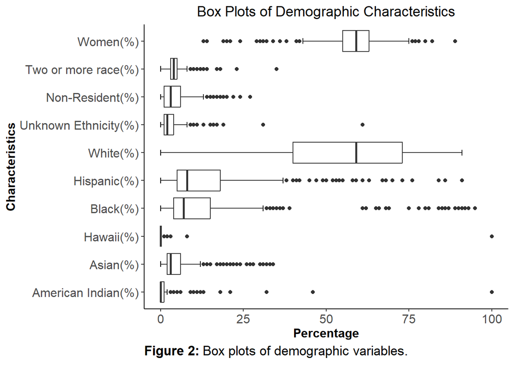

```r
# Using the dataframe created from above, graph box plots to determine outliers by demographics
demo.long %>%
  ggplot(aes(x = Characteristics, y = Percentage)) +
  stat_boxplot(geom = "errorbar", width = 0.2) +
  labs(title = "Box Plots of Demographic Characteristics",
        caption = bquote(bold("Figure 2:") ~ "Box plots of demographic variables.")) +
  geom_boxplot() +
  coord_flip() +
  theme_classic() +
  theme(plot.title = element_text(size = 14,
                                  hjust = 0.5),
        axis.title = element_text(size = 12,
                                  face = "bold"),
        axis.text = element_text(size = 12),
        plot.caption = element_text(size = 13,
                                    hjust = 0))
```

### Print out table indicate what the number labels represent

```r
# Set working directory
setwd("~/MISC/ELCS 8330")

# Load in the data labels
data.labels <- read.csv("mid term data labels.csv")

# Keep only the data labels that are in our study (aka applies to Carnegie)
data.carnegie.labels <- as.numeric(unique(data$Carnegie))


# Print the labels
Carnegie.labels <- data.labels %>%
  filter(VariableName == "Carnegie Classification 2021: Basic (HD2021)") %>%
  filter(Value %in% data.carnegie.labels) %>%
  select(-VariableName, Carnegie = Value) %>%
  mutate(Carnegie = as.character(Carnegie))


# Print the table
Carnegie.labels %>%
  kbl() %>%
  kable_paper(bootstrap_options = "striped", full_width = F)
```

| Carnegie | ValueLabel |
| --- | --- |
| 14 | Baccalaureate/Associate’s Colleges: Associate’s Dominant |
| 15 | Doctoral Universities: Very High Research Activity |
| 16 | Doctoral Universities: High Research Activity |
| 17 | Doctoral/Professional Universities |
| 18 | Master’s Colleges & Universities: Larger Programs |
| 19 | Master’s Colleges & Universities: Medium Programs |
| 20 | Master’s Colleges & Universities: Small Programs |
| 21 | Baccalaureate Colleges: Arts & Sciences Focus |
| 22 | Baccalaureate Colleges: Diverse Fields |
| 23 | Baccalaureate/Associate’s Colleges: Mixed Baccalaureate/Associate’s |
| 26 | Special Focus Four-Year: Other Health Professions Schools |
| 30 | Special Focus Four-Year: Arts, Music & Design Schools |
| 33 | Tribal Colleges |

### Create a table for the proportion of Carnegie in our sample

```r
# Introduce the Carnegie levels to our original dataset
data.Carnegie <- data %>%
  left_join(Carnegie.labels, by = "Carnegie")


# Let's take some descriptive statistics on our new Value Label
Carnegie.descriptives <- data.Carnegie %>%
  group_by(ValueLabel) %>%
  count() %>%
  rename(`Carnegie Classification` = ValueLabel,
         Count = n) %>%
  mutate(Percentage = round(Count/nrow(data.Carnegie),3)*100)

# Print the table
Carnegie.descriptives %>%
  nice_table(title = "Table 2: Descriptive Statistics of Carnegie Classifications") %>%
  bold(part = "header")
```

| Table 2: Descriptive Statistics of Carnegie Classifications Carnegie Classification | Table 2: Descriptive Statistics of Carnegie Classifications Count | Table 2: Descriptive Statistics of Carnegie Classifications Percentage |
| --- | --- | --- |
| Baccalaureate Colleges: Arts & Sciences Focus | 11 | 2.30 |
| Baccalaureate Colleges: Diverse Fields | 35 | 7.40 |
| Baccalaureate/Associate's Colleges: Associate's Dominant | 1 | 0.20 |
| Baccalaureate/Associate's Colleges: Mixed Baccalaureate/Associate's | 5 | 1.10 |
| Doctoral Universities: High Research Activity | 88 | 18.60 |
| Doctoral Universities: Very High Research Activity | 102 | 21.60 |
| Doctoral/Professional Universities | 29 | 6.10 |
| Master's Colleges & Universities: Larger Programs | 124 | 26.30 |
| Master's Colleges & Universities: Medium Programs | 43 | 9.10 |
| Master's Colleges & Universities: Small Programs | 29 | 6.10 |
| Special Focus Four-Year: Arts, Music & Design Schools | 2 | 0.40 |
| Special Focus Four-Year: Other Health Professions Schools | 1 | 0.20 |
| Tribal Colleges | 2 | 0.40 |

```r
# The number of unique Classifications in our sample
unique(data.uncleaned$Carnegie.Classification.2021..Basic..HD2021.)
```

```
 [1] 33 23 18 16 17 19 20 14  6 15 22  5 26  9 21  8 NA 31  7 27 30  4  2 25  3
[26] -2 32 29
```

```r
unique(Carnegie.descriptives$`Carnegie Classification`)
```

```
 [1] "Baccalaureate Colleges: Arts & Sciences Focus"
 [2] "Baccalaureate Colleges: Diverse Fields"
 [3] "Baccalaureate/Associate's Colleges: Associate's Dominant"
 [4] "Baccalaureate/Associate's Colleges: Mixed Baccalaureate/Associate's"
 [5] "Doctoral Universities: High Research Activity\n"
 [6] "Doctoral Universities: Very High Research Activity\n"
 [7] "Doctoral/Professional Universities\n"
 [8] "Master's Colleges & Universities: Larger Programs"
 [9] "Master's Colleges & Universities: Medium Programs"
[10] "Master's Colleges & Universities: Small Programs"
[11] "Special Focus Four-Year: Arts, Music & Design Schools"
[12] "Special Focus Four-Year: Other Health Professions Schools"
[13] "Tribal Colleges"
```

### Create a table for our dichotomous variables (Institution variables: HBCU, Land Grant and Tribal)

```r
# Add labels to HBCU
data.Institution <- data.Carnegie %>%
  transmute(HBCU = factor(HBCU,
                       levels = c(1,2),
                       labels =c("Yes","No")),
         Tribal = factor(Tribal,
                         levels = c(1,2),
                         labels =c("Yes","No")),
         Land.Grant = factor(Land.Grant,
                             levels = c(1,2),
                             labels =c("Land Grant Institution",
                                       "Not Land Grant Institution")))

Institutional.tibble <- tibble(HBUC = table(data.Institution$HBCU)) %>%
  cbind(tibble(Tribal = table(data.Institution$Tribal))) %>%
  cbind(tibble(Land.Grant = table(data.Institution$Land.Grant)))

Institutional.tibble$Status <- c("Yes", "No")

Institutional.tibble %>%
  pivot_longer(-Status, names_to = "Institutional Variables",
               values_to = "Count") %>%
  select(`Institutional Variables`, Status, Count) %>%
  arrange(`Institutional Variables`) %>%
  group_by(`Institutional Variables`) %>%
  mutate(Percentage = round(Count/sum(Count),3)*100) %>%
  nice_table(title = "Table 3: Counts and Percentage of Institutional Variables ") %>%
  bold(part = "header")
```

| Table 3: Counts and Percentage of Institutional Variables Institutional Variables | Table 3: Counts and Percentage of Institutional Variables Status | Table 3: Counts and Percentage of Institutional Variables Count | Table 3: Counts and Percentage of Institutional Variables Percentage |
| --- | --- | --- | --- |
| HBUC | Yes | 31 | 6.60 |
| HBUC | No | 441 | 93.40 |
| Land.Grant | Yes | 74 | 15.70 |
| Land.Grant | No | 398 | 84.30 |
| Tribal | Yes | 2 | 0.40 |
| Tribal | No | 470 | 99.60 |

### Descriptives of our last few covariates

```r
options(scipen=999) # Remove significant numbers

# Use the summary function for these last variables
summary(data$Federal)
```

```
      Min.    1st Qu.     Median       Mean    3rd Qu.       Max.
         0    2093180    7344790   63864556   38203412 1238624727
```

```r
#hist(data$Federal)

summary(data$State)
```

```
     Min.   1st Qu.    Median      Mean   3rd Qu.      Max.
        0    658956   3569960  11899852  11639575 165198880
```

```r
#hist(data$State)

# Now enrollment
summary(data$`Total Enrollment`)
```

```
   Min. 1st Qu.  Median    Mean 3rd Qu.    Max.
    534    4424    9353   14334   19816   80065
```

```r
#hist(data$`Total Enrollment`)

# Lastly percentage of admitted
summary(data$`Admitted(%)`)
```

```
   Min. 1st Qu.  Median    Mean 3rd Qu.    Max.
  11.00   70.00   83.00   78.47   91.00  100.00
```

```r
#hist(data$`Admitted(%)`)
```

# HW2: Assumptions

### Assummption 1: Normality

### Viewing our data

```r
# Create a histogram of the outcome variable
plot1 <- data %>%
  ggplot(aes(x = Graduation.Rate)) +
  geom_histogram(fill = "white",
                 color = "black",
                 bins = 15) +
  scale_y_continuous(expand = c(0,0), limits = c(0,100)) +
  theme_classic() +
  labs(title = "A histogram of graduation rate",
       x = "Graduation Rate",
       y = "Frequency",
       caption = bquote(bold("Figure 1:") ~ "A histogram of graduation rates.")) +
  theme(plot.title = element_text(size = 18,
                                  hjust = 0.5),
        axis.title = element_text(size = 12, face = "bold"),
        axis.text = element_text(size = 12),
        plot.caption = element_text(size = 15,
                                    hjust = 0))
```

### Shapiro Wilk Test

The null hypothesis of Shapiro-Wilk test is that the sample comes from the population distribution thus it will be normaly distributed. If our Shapiro-Wilk test is significant then that means we reject the null hypothesis- this we violate the assumotion of normality. That is what occurs in our data for our outcome variable.

```r
# Use a Shapiro Wilk's test on graduation rates.
shapiro.test(data$Graduation.Rate)
```

```
    Shapiro-Wilk normality test

data:  data$Graduation.Rate
W = 0.99092, p-value = 0.005356
```

### Assumption 2: Linearity

Does our predictor and outcome variable when place in a scatter plot look linearly? Looking at our scatterplot- we see a line form nicely.

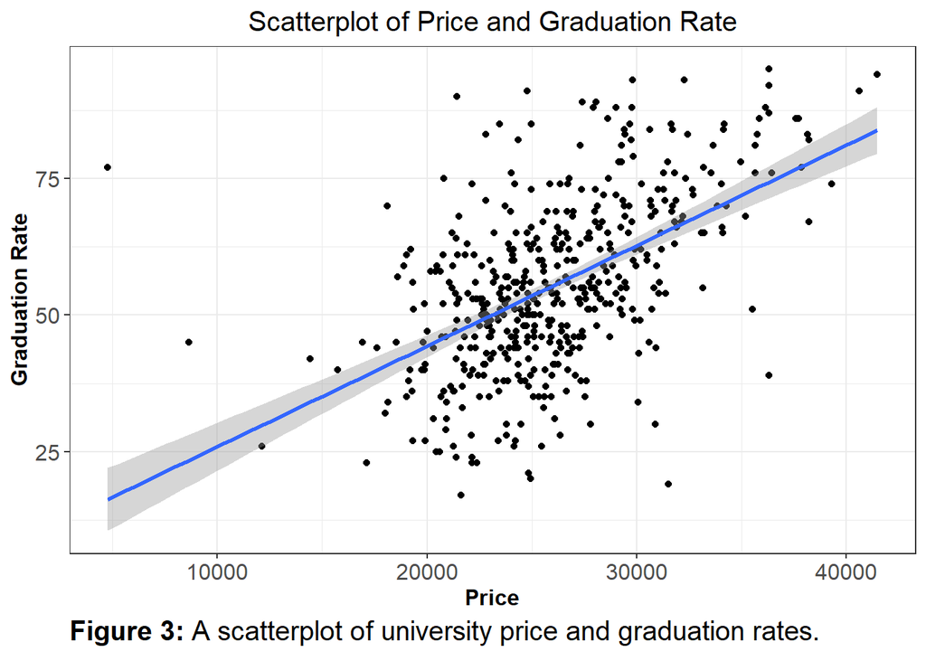

```r
# Create a scatterplot between the predictor and outcome variable
data %>%
  ggplot(aes(x = Price, y = Graduation.Rate)) +
  geom_point() +
  geom_smooth(method = "lm") +
  labs(title = "Scatterplot of Price and Graduation Rate",
       x = "Price",
       y = "Graduation Rate",
  caption = bquote(bold("Figure 3:") ~ "A scatterplot of university price and graduation rates.")) +
  theme_bw() +
  theme(plot.title = element_text(size = 15,
                                  hjust = 0.5),
        axis.title = element_text(size = 12, face = "bold"),
        axis.text = element_text(size = 12),
        plot.caption = element_text(size = 15,
                                    hjust = 0))
```

### Assumption 3: Homescedasticity

This assumption measures whether the variance of the outcome variable is similar accross different levels of the predictor variable. We can graph this in two ways- one as the way we did above with a scatterplot (which we will do again) and grouping variance into boxplots created by grouping quntiles of the predictor variable

### Visualizing the data

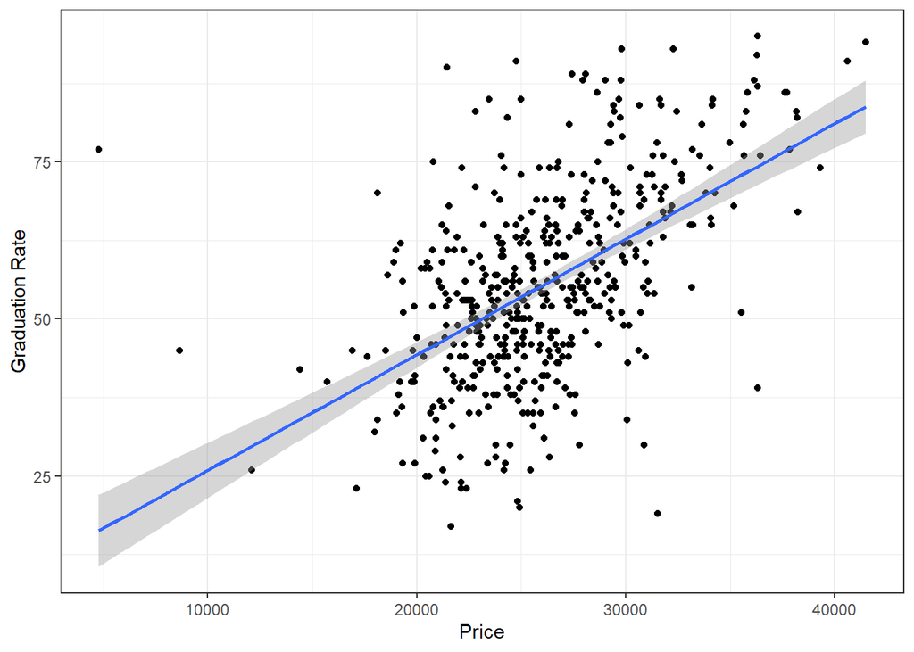

```r
# Graph the scatterplot and save it into an object
plot1 <- data %>%
  ggplot(aes(x = Price, y = Graduation.Rate)) +
  geom_point() +
  geom_smooth(method = "lm") +
  theme_bw() +
  labs(x = "Price",
       y = "Graduation Rate")

# Create the boxplots from perdictor quintiles
# Part 1: Obtain the quintiles of price and save it as a dataframe
quantile.df <- quantile(data$Price, probs = seq(0, 1, .2)) %>%
  data.frame(cut.off =.)

# Part 2: Create a new categorical variable defining which quintile the data belongs to
data.quant <- data %>%
  select(x = Price,
         y = Graduation.Rate) %>%
  arrange(x) %>%
  mutate(quant.x = ifelse(x < quantile.df$cut.off[2], "Q1",
                          ifelse(x < quantile.df$cut.off[3], "Q2",
                                 ifelse(x < quantile.df$cut.off[4], "Q3",
                                        ifelse(x < quantile.df$cut.off[5], "Q4", "Q5")))))

# Plot the quintiles of x as boxplots + jitter for our y
plot2 <- data.quant %>%
  ggplot(aes(x = quant.x, y = y)) +
  geom_boxplot() +
  theme_classic() +
  labs(title = "Graduation Rate Scores Grouped by Price Quintiles",
       x = "Price Quintiles",
       y = "Graduation Rate",
       caption = bquote(bold("Figure 4:") ~ "Box plots of graduation rate by price quintiles.")) +
  theme(plot.title = element_text(size = 15,
                                  hjust = 0.5),
        axis.title = element_text(size = 12, face = "bold"),
        axis.text = element_text(size = 12),
        plot.caption = element_text(size = 15,
                                    hjust = 0))


# Plot the graphs
#ggarrange(plot1, plot2)

plot1
```

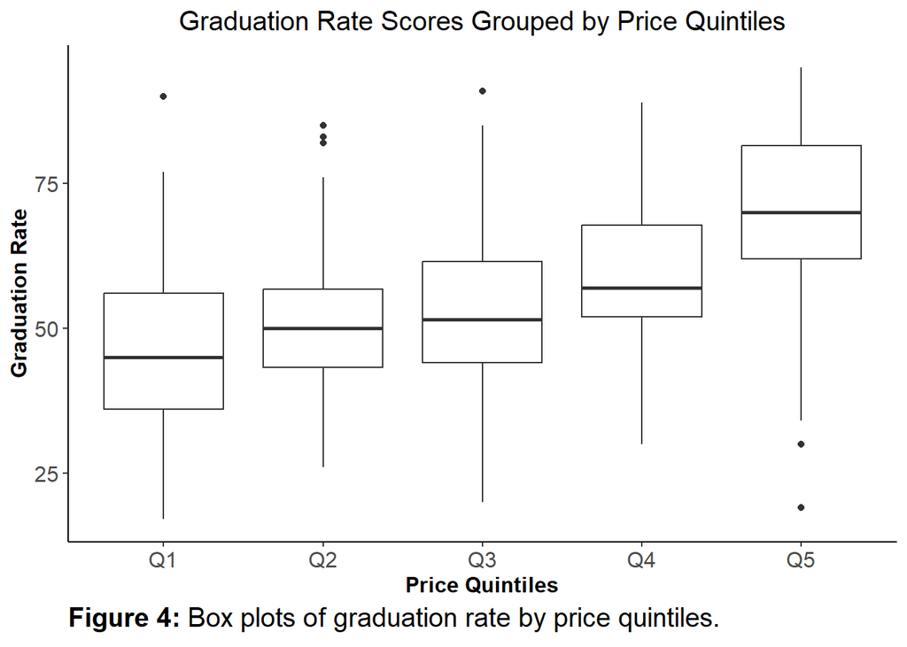

```r
plot2
```